# Logistic Regression Project

In this project we will be working with the UCI adult dataset. We will be attempting to predict if people in the data set belong in a certain class by salary, either making <=50k or >50k per year.

Typically most of your time is spent cleaning data, not running the few lines of code that build your model, this project will try to reflect that by showing different issues that may arise when cleaning data.

## Get the Data

**Read in the adult_sal.csv file and set it to a data frame called adult.**

**Check the head of adult**

|  | X | age | type_employer | fnlwgt | education | education_num | marital | occupation | relationship | race | sex | capital_gain | capital_loss | hr_per_week | country | income |
| --- | --- | --- | --- | --- | --- | --- | --- | --- | --- | --- | --- | --- | --- | --- | --- | --- |
| 1 | 1 | 39 | State-gov | 77516 | Bachelors | 13 | Never-married | Adm-clerical | Not-in-family | White | Male | 2174 | 0 | 40 | United-States | <=50K |
| 2 | 2 | 50 | Self-emp-not-inc | 83311 | Bachelors | 13 | Married-civ-spouse | Exec-managerial | Husband | White | Male | 0 | 0 | 13 | United-States | <=50K |
| 3 | 3 | 38 | Private | 215646 | HS-grad | 9 | Divorced | Handlers-cleaners | Not-in-family | White | Male | 0 | 0 | 40 | United-States | <=50K |
| 4 | 4 | 53 | Private | 234721 | 11th | 7 | Married-civ-spouse | Handlers-cleaners | Husband | Black | Male | 0 | 0 | 40 | United-States | <=50K |
| 5 | 5 | 28 | Private | 338409 | Bachelors | 13 | Married-civ-spouse | Prof-specialty | Wife | Black | Female | 0 | 0 | 40 | Cuba | <=50K |
| 6 | 6 | 37 | Private | 284582 | Masters | 14 | Married-civ-spouse | Exec-managerial | Wife | White | Female | 0 | 0 | 40 | United-States | <=50K |

**You should notice the index has been repeated. Drop this column.**

```r
library(dplyr)
adult <- select(adult,-X)
```

**Check the head,str, and summary of the data now.**

## Data Cleaning

Notice that we have a lot of columns that are cateogrical factors, however a lot of these columns have too many factors than may be necessary. In this data cleaning section we'll try to clean these columns up by reducing the number of factors.

### type_employer column

**Use table() to check out the frequency of the type_employer column.**

```
               ?      Federal-gov        Local-gov     Never-worked
            1836              960             2093                7
         Private     Self-emp-inc Self-emp-not-inc        State-gov
           22696             1116             2541             1298
     Without-pay
              14
```

**How many Null values are there for type_employer? What are the two smallest groups?**

**Combine these two smallest groups into a single group called "Unemployed". There are lots of ways to do this, so feel free to get creative. Hint: It may be helpful to convert these objects into character data types (as.character() and then use sapply with a custom function)**

```
               ?      Federal-gov        Local-gov          Private
            1836              960             2093            22696
    Self-emp-inc Self-emp-not-inc        State-gov       Unemployed
            1116             2541             1298               21
```

**What other columns are suitable for combining? Combine State and Local gov jobs into a category called SL-gov and combine self-employed jobs into a category called self-emp.**

```
          ? Federal-gov     Private    self-emp      SL-gov  Unemployed
       1836         960       22696        3657        3391          21
```

### Marital Column

**Use table() to look at the marital column**

```
             Divorced     Married-AF-spouse    Married-civ-spouse
                 4443                    23                 14976
Married-spouse-absent         Never-married             Separated
                  418                 10683                  1025
              Widowed
                  993
```

**Reduce this to three groups:**

- Married
- Not-Married
- Never-Married

```
      Married Never-married   Not-Married
        15417         10683          6461
```

### Country Column

**Check the country column using table()**

```
                         ?                   Cambodia
                       583                         19
                    Canada                      China
                       121                         75
                  Columbia                       Cuba
                        59                         95
        Dominican-Republic                    Ecuador
                        70                         28
               El-Salvador                    England
                       106                         90
                    France                    Germany
                        29                        137
                    Greece                  Guatemala
                        29                         64
                     Haiti         Holand-Netherlands
                        44                          1
                  Honduras                       Hong
                        13                         20
                   Hungary                      India
                        13                        100
                      Iran                    Ireland
                        43                         24
                     Italy                    Jamaica
                        73                         81
                     Japan                       Laos
                        62                         18
                    Mexico                  Nicaragua
                       643                         34
Outlying-US(Guam-USVI-etc)                       Peru
                        14                         31
               Philippines                     Poland
                       198                         60
                  Portugal                Puerto-Rico
                        37                        114
                  Scotland                      South
                        12                         80
                    Taiwan                   Thailand
                        51                         18
           Trinadad&Tobago              United-States
                        19                      29170
                   Vietnam                 Yugoslavia
                        67                         16
```

**Group these countries together however you see fit. You have flexibility here because there is no right/wrong way to do this, possibly group by continents. You should be able to reduce the number of groups here significantly though.**

1. '?'

2. 'Cambodia'

3. 'Canada'

4. 'China'

5. 'Columbia'

6. 'Cuba'

7. 'Dominican-Republic'

8. 'Ecuador'

9. 'El-Salvador'

10. 'England'

11. 'France'

12. 'Germany'

13. 'Greece'

14. 'Guatemala'

15. 'Haiti'

16. 'Holand-Netherlands'

17. 'Honduras'

18. 'Hong'

19. 'Hungary'

20. 'India'

21. 'Iran'

22. 'Ireland'

23. 'Italy'

24. 'Jamaica'

25. 'Japan'

26. 'Laos'

27. 'Mexico'

28. 'Nicaragua'

29. 'Outlying-US(Guam-USVI-etc)'

30. 'Peru'

31. 'Philippines'

32. 'Poland'

33. 'Portugal'

34. 'Puerto-Rico'

35. 'Scotland'

36. 'South'

37. 'Taiwan'

38. 'Thailand'

39. 'Trinadad&Tobago'

40. 'United-States'

41. 'Vietnam'

42. 'Yugoslavia'

**Use table() to confirm the groupings**

```
                   Asia                  Europe Latin.and.South.America
                    671                     521                    1301
          North.America                   Other
                  29405                     663
```

**Check the str() of adult again. Make sure any of the columns we changed have factor levels with factor()**

**We could still play around with education and occupation to try to reduce the number of factors for those columns, but let's go ahead and move on to dealing with the missing data. Feel free to group thos columns as well and see how they effect your model.**

## Missing Data

Notice how we have data that is missing.

### Amelia

**Install and load the Amelia package.**

```r
#install.packages('Amelia',repos = 'http://cran.us.r-project.org')
library(Amelia)
```

**Convert any cell with a '?' or a ' ?' value to a NA value. Hint: is.na() may be useful here or you can also use brackets with a conditional statement. Refer to the solutions if you can't figure this step out.**

**Using table() on a column with NA values should now not display those NA values, instead you'll just see 0 for ?. Optional: Refactor these columns (may take awhile). For example:**

```
     SL-gov    self-emp     Private Federal-gov           ?  Unemployed
       3391        3657       22696         960           0          21
```

**Play around with the missmap function from the Amelia package. Can you figure out what its doing and how to use it?**

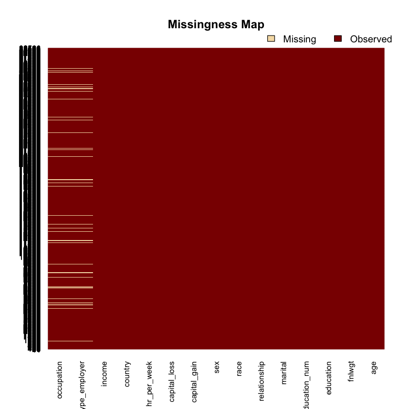

**You should have noticed that using missmap(adult) is bascially a heatmap pointing out missing values (NA). This gives you a quick glance at how much data is missing, in this case, not a whole lot (relatively speaking). You probably also noticed that there is a bunch of y labels, get rid of them by running the command below. What is col=c('yellow','black') doing?**

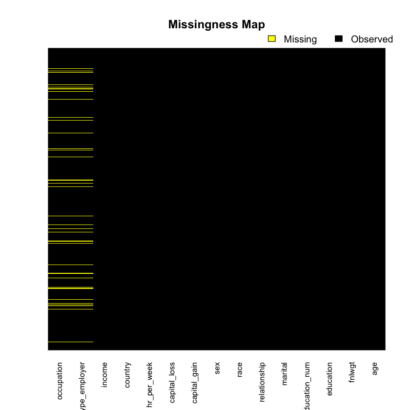

```r
missmap(adult,y.at=c(1),y.labels = c(''),col=c('yellow','black'))
```

**Use na.omit() to omit NA data from the adult data frame. Note, it really depends on the situation and your data to judge whether or not this is a good decision. You shouldn't always just drop NA values.**

```r
# May take awhile

#str(adult)
```

**Use missmap() to check that all the NA values were in fact dropped.**

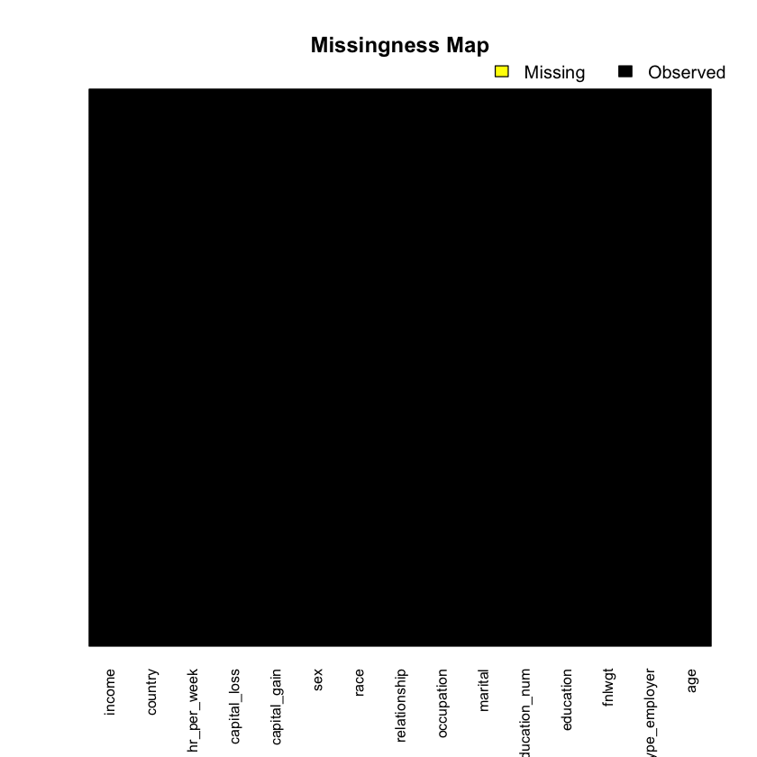

# EDA

Although we've cleaned the data, we still have explored it using visualization.

**Check the str() of the data.**

```
'data.frame':	30718 obs. of  15 variables:
 $ age          : int  39 50 38 53 28 37 49 52 31 42 ...
 $ type_employer: Factor w/ 5 levels "SL-gov","self-emp",..: 1 2 3 3 3 3 3 2 3 3 ...
 $ fnlwgt       : int  77516 83311 215646 234721 338409 284582 160187 209642 45781 159449 ...
 $ education    : Factor w/ 16 levels "10th","11th",..: 10 10 12 2 10 13 7 12 13 10 ...
 $ education_num: int  13 13 9 7 13 14 5 9 14 13 ...
 $ marital      : Factor w/ 3 levels "Never-married",..: 1 2 3 2 2 2 2 2 1 2 ...
 $ occupation   : Factor w/ 14 levels "Adm-clerical",..: 1 2 3 3 4 2 5 2 4 2 ...
 $ relationship : Factor w/ 6 levels "Husband","Not-in-family",..: 2 1 2 1 6 6 2 1 2 1 ...
 $ race         : Factor w/ 5 levels "Amer-Indian-Eskimo",..: 5 5 5 3 3 5 3 5 5 5 ...
 $ sex          : Factor w/ 2 levels "Female","Male": 2 2 2 2 1 1 1 2 1 2 ...
 $ capital_gain : int  2174 0 0 0 0 0 0 0 14084 5178 ...
 $ capital_loss : int  0 0 0 0 0 0 0 0 0 0 ...
 $ hr_per_week  : int  40 13 40 40 40 40 16 45 50 40 ...
 $ country      : Factor w/ 5 levels "North.America",..: 1 1 1 1 2 1 2 1 1 1 ...
 $ income       : Factor w/ 2 levels "<=50K",">50K": 1 1 1 1 1 1 1 2 2 2 ...
 - attr(*, "na.action")=Class 'omit'  Named int [1:1843] 28 62 70 78 107 129 150 155 161 188 ...
  .. ..- attr(*, "names")= chr [1:1843] "28" "62" "70" "78" ...
```

**Use ggplot2 to create a histogram of ages, colored by income.**

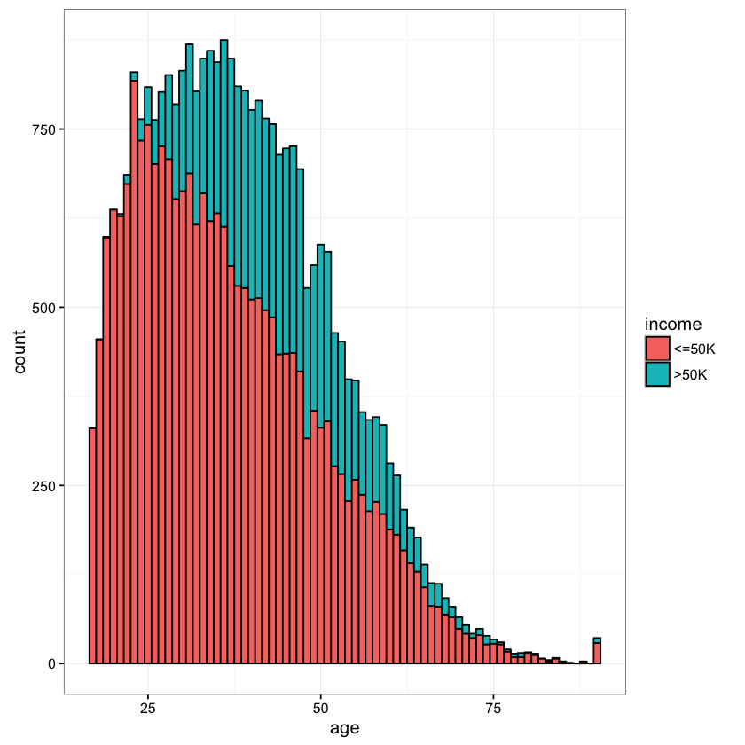

**Plot a histogram of hours worked per week**

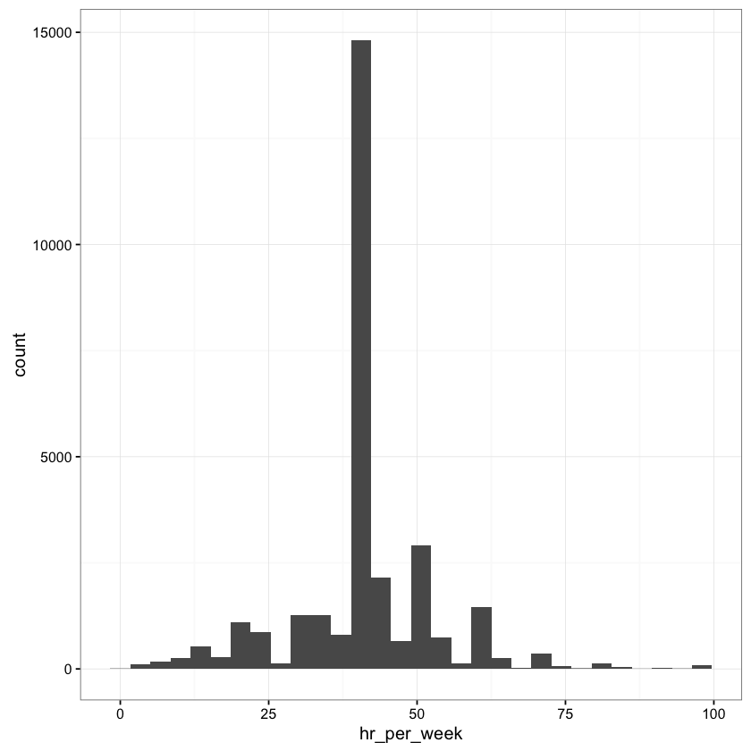

**Rename the country column to region column to better reflect the factor levels.**

**Create a barplot of region with the fill color defined by income class. Optional: Figure out how rotate the x axis text for readability**

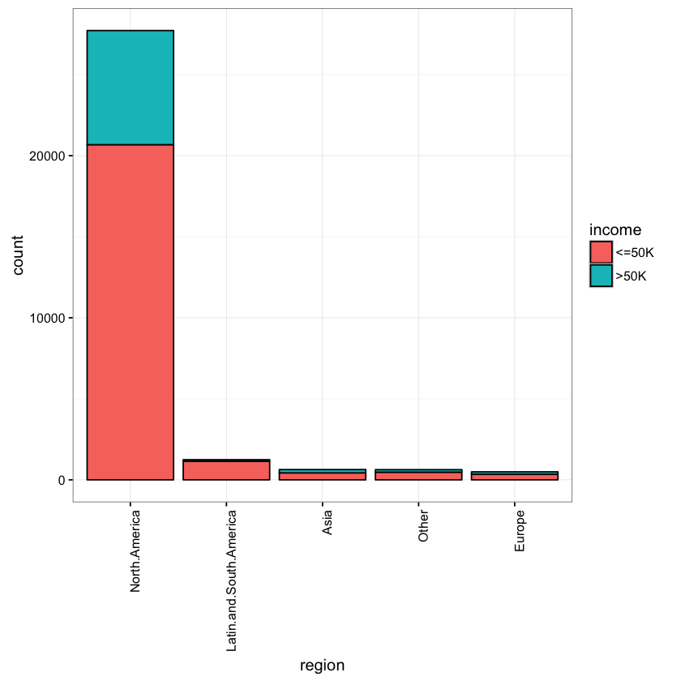

# Building a Model

Now it's time to build a model to classify people into two groups: Above or Below 50k in Salary.

## Logistic Regression

Refer to the Lecture or ISLR if you are fuzzy on any of this.

Logistic Regression is a type of classification model. In classification models, we attempt to predict the outcome of categorical dependent variables, using one or more independent variables. The independent variables can be either categorical or numerical.

Logistic regression is based on the logistic function, which always takes values between 0 and 1. Replacing the dependent variable of the logistic function with a linear combination of dependent variables we intend to use for regression, we arrive at the formula for logistic regression.

**Take a quick look at the head() of adult to make sure we have a good overview before going into building the model!**

|  | age | type_employer | fnlwgt | education | education_num | marital | occupation | relationship | race | sex | capital_gain | capital_loss | hr_per_week | region | income |
| --- | --- | --- | --- | --- | --- | --- | --- | --- | --- | --- | --- | --- | --- | --- | --- |
| 1 | 39 | SL-gov | 77516 | Bachelors | 13 | Never-married | Adm-clerical | Not-in-family | White | Male | 2174 | 0 | 40 | North.America | <=50K |
| 2 | 50 | self-emp | 83311 | Bachelors | 13 | Married | Exec-managerial | Husband | White | Male | 0 | 0 | 13 | North.America | <=50K |
| 3 | 38 | Private | 215646 | HS-grad | 9 | Not-Married | Handlers-cleaners | Not-in-family | White | Male | 0 | 0 | 40 | North.America | <=50K |
| 4 | 53 | Private | 234721 | 11th | 7 | Married | Handlers-cleaners | Husband | Black | Male | 0 | 0 | 40 | North.America | <=50K |
| 5 | 28 | Private | 338409 | Bachelors | 13 | Married | Prof-specialty | Wife | Black | Female | 0 | 0 | 40 | Latin.and.South.America | <=50K |
| 6 | 37 | Private | 284582 | Masters | 14 | Married | Exec-managerial | Wife | White | Female | 0 | 0 | 40 | North.America | <=50K |

## Train Test Split

**Split the data into a train and test set using the caTools library as done in previous lectures. Reference previous solutions notebooks if you need a refresher.**

## Training the Model

**Explore the glm() function with help(glm). Read through the documentation.**

```r
help(glm)
```

| glm {stats} | R Documentation |
| --- | --- |

Fitting Generalized Linear Models

Description

`glm` is used to fit generalized linear models, specified by giving a symbolic description of the linear predictor and a description of the error distribution.

Usage

```
glm(formula, family = gaussian, data, weights, subset,
    na.action, start = NULL, etastart, mustart, offset,
    control = list(...), model = TRUE, method = "glm.fit",
    x = FALSE, y = TRUE, contrasts = NULL, ...)

glm.fit(x, y, weights = rep(1, nobs),
        start = NULL, etastart = NULL, mustart = NULL,
        offset = rep(0, nobs), family = gaussian(),
        control = list(), intercept = TRUE)

## S3 method for class 'glm'
weights(object, type = c("prior", "working"), ...)
```

Arguments

| `formula` | an object of class `"formula"` (or one that can be coerced to that class): a symbolic description of the model to be fitted. The details of model specification are given under ‘Details’. |
| --- | --- |
| `family` | a description of the error distribution and link function to be used in the model. For `glm` this can be a character string naming a family function, a family function or the result of a call to a fam… |
| `data` | an optional data frame, list or environment (or object coercible by `as.data.frame` to a data frame) containing the variables in the model. If not found in `data`, the variables are taken from `enviro… |
| `weights` | an optional vector of ‘prior weights’ to be used in the fitting process. Should be `NULL` or a numeric vector. |
| `subset` | an optional vector specifying a subset of observations to be used in the fitting process. |
| `na.action` | a function which indicates what should happen when the data contain `NA`s. The default is set by the `na.action` setting of `options`, and is `na.fail` if that is unset. The ‘factory-fresh’ default is… |
| `start` | starting values for the parameters in the linear predictor. |
| `etastart` | starting values for the linear predictor. |
| `mustart` | starting values for the vector of means. |
| `offset` | this can be used to specify an *a priori* known component to be included in the linear predictor during fitting. This should be `NULL` or a numeric vector of length equal to the number of cases. One o… |
| `control` | a list of parameters for controlling the fitting process. For `glm.fit` this is passed to `glm.control`. |
| `model` | a logical value indicating whether *model frame* should be included as a component of the returned value. |
| `method` | the method to be used in fitting the model. The default method `"glm.fit"` uses iteratively reweighted least squares (IWLS): the alternative `"model.frame"` returns the model frame and does no fitting… |
| `x, y` | For `glm`: logical values indicating whether the response vector and model matrix used in the fitting process should be returned as components of the returned value. For `glm.fit`: `x` is a design mat… |
| `contrasts` | an optional list. See the `contrasts.arg` of `model.matrix.default`. |
| `intercept` | logical. Should an intercept be included in the *null* model? |
| `object` | an object inheriting from class `"glm"`. |
| `type` | character, partial matching allowed. Type of weights to extract from the fitted model object. Can be abbreviated. |
| `...` | For `glm`: arguments to be used to form the default `control` argument if it is not supplied directly. For `weights`: further arguments passed to or from other methods. |

Details

A typical predictor has the form `response ~ terms` where `response` is the (numeric) response vector and `terms` is a series of terms which specifies a linear predictor for `response`. For `binomial` and `quasibinomial` families the response can also be specified as a `factor` (when the first level denotes failure and all others success) or as a two-column matrix with the columns giving the numbers of successes and failures. A terms specification of the form `first + second` indicates all the terms in `first` together with all the terms in `second` with any duplicates removed.

A specification of the form `first:second` indicates the set of terms obtained by taking the interactions of all terms in `first` with all terms in `second`. The specification `first*second` indicates the *cross* of `first` and `second`. This is the same as

```
first + second +
  first:second
```

.

The terms in the formula will be re-ordered so that main effects come first, followed by the interactions, all second-order, all third-order and so on: to avoid this pass a `terms` object as the formula.

Non-`NULL` `weights` can be used to indicate that different observations have different dispersions (with the values in `weights` being inversely proportional to the dispersions); or equivalently, when the elements of `weights` are positive integers *w_i*, that each response *y_i* is the mean of *w_i* unit-weight observations. For a binomial GLM prior weights are used to give the number of trials when the response is the proportion of successes: they would rarely be used for a Poisson GLM.

`glm.fit` is the workhorse function: it is not normally called directly but can be more efficient where the response vector, design matrix and family have already been calculated.

If more than one of `etastart`, `start` and `mustart` is specified, the first in the list will be used. It is often advisable to supply starting values for a `quasi` family, and also for families with unusual links such as `gaussian("log")`.

All of `weights`, `subset`, `offset`, `etastart` and `mustart` are evaluated in the same way as variables in `formula`, that is first in `data` and then in the environment of `formula`.

For the background to warning messages about ‘fitted probabilities numerically 0 or 1 occurred’ for binomial GLMs, see Venables & Ripley (2002, pp. 197–8).

Value

`glm` returns an object of class inheriting from `"glm"` which inherits from the class `"lm"`. See later in this section. If a non-standard `method` is used, the object will also inherit from the class (if any) returned by that function.

The function `summary` (i.e., `summary.glm`) can be used to obtain or print a summary of the results and the function `anova` (i.e., `anova.glm`) to produce an analysis of variance table.

The generic accessor functions `coefficients`, `effects`, `fitted.values` and `residuals` can be used to extract various useful features of the value returned by `glm`.

`weights` extracts a vector of weights, one for each case in the fit (after subsetting and `na.action`).

An object of class `"glm"` is a list containing at least the following components:

| `coefficients` | a named vector of coefficients |
| --- | --- |
| `residuals` | the *working* residuals, that is the residuals in the final iteration of the IWLS fit. Since cases with zero weights are omitted, their working residuals are `NA`. |
| `fitted.values` | the fitted mean values, obtained by transforming the linear predictors by the inverse of the link function. |
| `rank` | the numeric rank of the fitted linear model. |
| `family` | the `family` object used. |
| `linear.predictors` | the linear fit on link scale. |
| `deviance` | up to a constant, minus twice the maximized log-likelihood. Where sensible, the constant is chosen so that a saturated model has deviance zero. |
| `aic` | A version of Akaike's *An Information Criterion*, minus twice the maximized log-likelihood plus twice the number of parameters, computed by the `aic` component of the family. For binomial and Poison f… |
| `null.deviance` | The deviance for the null model, comparable with `deviance`. The null model will include the offset, and an intercept if there is one in the model. Note that this will be incorrect if the link functio… |
| `iter` | the number of iterations of IWLS used. |
| `weights` | the *working* weights, that is the weights in the final iteration of the IWLS fit. |
| `prior.weights` | the weights initially supplied, a vector of `1`s if none were. |
| `df.residual` | the residual degrees of freedom. |
| `df.null` | the residual degrees of freedom for the null model. |
| `y` | if requested (the default) the `y` vector used. (It is a vector even for a binomial model.) |
| `x` | if requested, the model matrix. |
| `model` | if requested (the default), the model frame. |
| `converged` | logical. Was the IWLS algorithm judged to have converged? |
| `boundary` | logical. Is the fitted value on the boundary of the attainable values? |
| `call` | the matched call. |
| `formula` | the formula supplied. |
| `terms` | the `terms` object used. |
| `data` | the `data argument`. |
| `offset` | the offset vector used. |
| `control` | the value of the `control` argument used. |
| `method` | the name of the fitter function used, currently always `"glm.fit"`. |
| `contrasts` | (where relevant) the contrasts used. |
| `xlevels` | (where relevant) a record of the levels of the factors used in fitting. |
| `na.action` | (where relevant) information returned by `model.frame` on the special handling of `NA`s. |

In addition, non-empty fits will have components `qr`, `R` and `effects` relating to the final weighted linear fit.

Objects of class `"glm"` are normally of class

```
c("glm",
    "lm")
```

, that is inherit from class `"lm"`, and well-designed methods for class `"lm"` will be applied to the weighted linear model at the final iteration of IWLS. However, care is needed, as extractor functions for class `"glm"` such as `residuals` and `weights` do **not** just pick out the component of the fit with the same name.

If a `binomial` `glm` model was specified by giving a two-column response, the weights returned by `prior.weights` are the total numbers of cases (factored by the supplied case weights) and the component `y` of the result is the proportion of successes.

Fitting functions

The argument `method` serves two purposes. One is to allow the model frame to be recreated with no fitting. The other is to allow the default fitting function `glm.fit` to be replaced by a function which takes the same arguments and uses a different fitting algorithm. If `glm.fit` is supplied as a character string it is used to search for a function of that name, starting in the stats namespace.

The class of the object return by the fitter (if any) will be prepended to the class returned by `glm`.

Author(s)

The original **R** implementation of `glm` was written by Simon Davies working for Ross Ihaka at the University of Auckland, but has since been extensively re-written by members of the R Core team.

The design was inspired by the S function of the same name described in Hastie & Pregibon (1992).

References

Dobson, A. J. (1990) *An Introduction to Generalized Linear Models.* London: Chapman and Hall.

Hastie, T. J. and Pregibon, D. (1992) *Generalized linear models.* Chapter 6 of *Statistical Models in S* eds J. M. Chambers and T. J. Hastie, Wadsworth & Brooks/Cole.

McCullagh P. and Nelder, J. A. (1989) *Generalized Linear Models.* London: Chapman and Hall.

Venables, W. N. and Ripley, B. D. (2002) *Modern Applied Statistics with S.* New York: Springer.

See Also

`anova.glm`, `summary.glm`, etc. for `glm` methods, and the generic functions `anova`, `summary`, `effects`, `fitted.values`, and `residuals`.

`lm` for non-generalized *linear* models (which SAS calls GLMs, for ‘general’ linear models).

`loglin` and `loglm` (package MASS) for fitting log-linear models (which binomial and Poisson GLMs are) to contingency tables.

`bigglm` in package biglm for an alternative way to fit GLMs to large datasets (especially those with many cases).

`esoph`, `infert` and `predict.glm` have examples of fitting binomial glms.

Examples

```
## Dobson (1990) Page 93: Randomized Controlled Trial :
counts <- c(18,17,15,20,10,20,25,13,12)
outcome <- gl(3,1,9)
treatment <- gl(3,3)
print(d.AD <- data.frame(treatment, outcome, counts))
glm.D93 <- glm(counts ~ outcome + treatment, family = poisson())
anova(glm.D93)
summary(glm.D93)

## an example with offsets from Venables & Ripley (2002, p.189)
utils::data(anorexia, package = "MASS")

anorex.1 <- glm(Postwt ~ Prewt + Treat + offset(Prewt),
                family = gaussian, data = anorexia)
summary(anorex.1)


# A Gamma example, from McCullagh & Nelder (1989, pp. 300-2)
clotting <- data.frame(
    u = c(5,10,15,20,30,40,60,80,100),
    lot1 = c(118,58,42,35,27,25,21,19,18),
    lot2 = c(69,35,26,21,18,16,13,12,12))
summary(glm(lot1 ~ log(u), data = clotting, family = Gamma))
summary(glm(lot2 ~ log(u), data = clotting, family = Gamma))

## Not run:
## for an example of the use of a terms object as a formula
demo(glm.vr)

## End(Not run)
```

[Package *stats* version 3.2.2 ]

**Use all the features to train a glm() model on the training data set, pass the argument family=binomial(logit) into the glm function.**

```
Warning message:
: glm.fit: fitted probabilities numerically 0 or 1 occurred
```

**If you get a warning, this just means that the model may have guessed the probability of a class with a 0% or 100% chance of occuring.**

**Check the model summary**

```
Call:
glm(formula = income ~ ., family = binomial(logit), data = train)

Deviance Residuals:
    Min       1Q   Median       3Q      Max
-5.1163  -0.5172  -0.1965   0.0000   3.6235

Coefficients: (1 not defined because of singularities)
                                Estimate Std. Error z value Pr(>|z|)
(Intercept)                   -7.364e+00  4.245e-01 -17.346  < 2e-16 ***
age                            2.534e-02  2.007e-03  12.627  < 2e-16 ***
type_employerself-emp          7.501e-03  8.999e-02   0.083 0.933571
type_employerPrivate           2.371e-01  7.321e-02   3.239 0.001198 **
type_employerFederal-gov       6.835e-01  1.266e-01   5.399 6.71e-08 ***
type_employerUnemployed       -1.346e+01  3.688e+02  -0.036 0.970888
fnlwgt                         5.424e-07  2.085e-07   2.601 0.009291 **
education11th                  2.094e-01  2.570e-01   0.814 0.415384
education12th                  3.925e-01  3.410e-01   1.151 0.249612
education1st-4th              -4.590e-01  6.067e-01  -0.757 0.449323
education5th-6th              -8.009e-02  3.980e-01  -0.201 0.840503
education7th-8th              -4.991e-01  2.880e-01  -1.733 0.083096 .
education9th                  -1.229e-02  3.191e-01  -0.038 0.969292
educationAssoc-acdm            1.250e+00  2.165e-01   5.775 7.70e-09 ***
educationAssoc-voc             1.452e+00  2.084e-01   6.970 3.17e-12 ***
educationBachelors             2.003e+00  1.938e-01  10.337  < 2e-16 ***
educationDoctorate             2.874e+00  2.636e-01  10.902  < 2e-16 ***
educationHS-grad               8.359e-01  1.888e-01   4.426 9.58e-06 ***
educationMasters               2.347e+00  2.063e-01  11.374  < 2e-16 ***
educationPreschool            -1.879e+01  1.645e+02  -0.114 0.909053
educationProf-school           2.797e+00  2.468e-01  11.337  < 2e-16 ***
educationSome-college          1.203e+00  1.915e-01   6.283 3.33e-10 ***
education_num                         NA         NA      NA       NA
maritalMarried                 1.280e+00  1.943e-01   6.588 4.45e-11 ***
maritalNot-Married             5.435e-01  9.953e-02   5.460 4.75e-08 ***
occupationExec-managerial      7.689e-01  9.095e-02   8.453  < 2e-16 ***
occupationHandlers-cleaners   -7.944e-01  1.726e-01  -4.603 4.17e-06 ***
occupationProf-specialty       4.957e-01  9.626e-02   5.149 2.62e-07 ***
occupationOther-service       -8.248e-01  1.386e-01  -5.952 2.65e-09 ***
occupationSales                2.896e-01  9.749e-02   2.971 0.002972 **
occupationCraft-repair         4.151e-02  9.483e-02   0.438 0.661616
```

[output cut: 19 more lines]

```
hr_per_week                    2.906e-02  1.987e-03  14.623  < 2e-16 ***
regionLatin.and.South.America -5.925e-01  1.595e-01  -3.714 0.000204 ***
regionAsia                    -6.475e-02  2.044e-01  -0.317 0.751446
regionOther                   -4.300e-01  1.651e-01  -2.604 0.009206 **
regionEurope                   4.404e-02  1.552e-01   0.284 0.776660
---
Signif. codes:  0 ‘***’ 0.001 ‘**’ 0.01 ‘*’ 0.05 ‘.’ 0.1 ‘ ’ 1

(Dispersion parameter for binomial family taken to be 1)

    Null deviance: 24138  on 21502  degrees of freedom
Residual deviance: 14004  on 21449  degrees of freedom
AIC: 14112

Number of Fisher Scoring iterations: 14
```

**We have still a lot of features! Some important, some not so much. R comes with an *awesome* function called step(). The step() function iteratively tries to remove predictor variables from the model in an attempt to delete variables that do not significantly add to the fit. How does it do this? It uses [AIC](https://en.wikipedia.org/wiki/Akaike_information_criterion). Read the wikipedia page for AIC if you want to further understand this, you can also check out help(step). This level of statistics is outside the scope of this project assignment so let's keep moving along**

```r
help(step)
```

| step {stats} | R Documentation |
| --- | --- |

Choose a model by AIC in a Stepwise Algorithm

Description

Select a formula-based model by AIC.

Usage

```
step(object, scope, scale = 0,
     direction = c("both", "backward", "forward"),
     trace = 1, keep = NULL, steps = 1000, k = 2, ...)
```

Arguments

| `object` | an object representing a model of an appropriate class (mainly `"lm"` and `"glm"`). This is used as the initial model in the stepwise search. |
| --- | --- |
| `scope` | defines the range of models examined in the stepwise search. This should be either a single formula, or a list containing components `upper` and `lower`, both formulae. See the details for how to spec… |
| `scale` | used in the definition of the AIC statistic for selecting the models, currently only for `lm`, `aov` and `glm` models. The default value, `0`, indicates the scale should be estimated: see `extractAIC`… |
| `direction` | the mode of stepwise search, can be one of `"both"`, `"backward"`, or `"forward"`, with a default of `"both"`. If the `scope` argument is missing the default for `direction` is `"backward"`. Values ca… |
| `trace` | if positive, information is printed during the running of `step`. Larger values may give more detailed information. |
| `keep` | a filter function whose input is a fitted model object and the associated `AIC` statistic, and whose output is arbitrary. Typically `keep` will select a subset of the components of the object and retu… |
| `steps` | the maximum number of steps to be considered. The default is 1000 (essentially as many as required). It is typically used to stop the process early. |
| `k` | the multiple of the number of degrees of freedom used for the penalty. Only `k = 2` gives the genuine AIC: `k = log(n)` is sometimes referred to as BIC or SBC. |
| `...` | any additional arguments to `extractAIC`. |

Details

`step` uses `add1` and `drop1` repeatedly; it will work for any method for which they work, and that is determined by having a valid method for `extractAIC`. When the additive constant can be chosen so that AIC is equal to Mallows' *Cp*, this is done and the tables are labelled appropriately.

The set of models searched is determined by the `scope` argument. The right-hand-side of its `lower` component is always included in the model, and right-hand-side of the model is included in the `upper` component. If `scope` is a single formula, it specifies the `upper` component, and the `lower` model is empty. If `scope` is missing, the initial model is used as the `upper` model.

Models specified by `scope` can be templates to update `object` as used by `update.formula`. So using `.` in a `scope` formula means ‘what is already there’, with `.^2` indicating all interactions of existing terms.

There is a potential problem in using `glm` fits with a variable `scale`, as in that case the deviance is not simply related to the maximized log-likelihood. The `"glm"` method for function `extractAIC` makes the appropriate adjustment for a `gaussian` family, but may need to be amended for other cases. (The `binomial` and `poisson` families have fixed `scale` by default and do not correspond to a particular maximum-likelihood problem for variable `scale`.)

Value

the stepwise-selected model is returned, with up to two additional components. There is an `"anova"` component corresponding to the steps taken in the search, as well as a `"keep"` component if the `keep=` argument was supplied in the call. The `"Resid. Dev"` column of the analysis of deviance table refers to a constant minus twice the maximized log likelihood: it will be a deviance only in cases where a saturated model is well-defined (thus excluding `lm`, `aov` and `survreg` fits, for example).

Warning

The model fitting must apply the models to the same dataset. This may be a problem if there are missing values and **R**'s default of `na.action = na.omit` is used. We suggest you remove the missing values first.

Calls to the function `nobs` are used to check that the number of observations involved in the fitting process remains unchanged.

Note

This function differs considerably from the function in S, which uses a number of approximations and does not in general compute the correct AIC.

This is a minimal implementation. Use `stepAIC` in package MASS for a wider range of object classes.

Author(s)

B. D. Ripley: `step` is a slightly simplified version of `stepAIC` in package MASS (Venables & Ripley, 2002 and earlier editions).

The idea of a `step` function follows that described in Hastie & Pregibon (1992); but the implementation in **R** is more general.

References

Hastie, T. J. and Pregibon, D. (1992) *Generalized linear models.* Chapter 6 of *Statistical Models in S* eds J. M. Chambers and T. J. Hastie, Wadsworth & Brooks/Cole.

Venables, W. N. and Ripley, B. D. (2002) *Modern Applied Statistics with S.* New York: Springer (4th ed).

See Also

`stepAIC` in MASS, `add1`, `drop1`

Examples

```
## following on from example(lm)

step(lm.D9)

summary(lm1 <- lm(Fertility ~ ., data = swiss))
slm1 <- step(lm1)
summary(slm1)
slm1$anova
```

[Package *stats* version 3.2.2 ]

**Use new.model <- step(your.model.name) to use the step() function to create a new model.**

```
Start:  AIC=14112.05
income ~ age + type_employer + fnlwgt + education + education_num +
    marital + occupation + relationship + race + sex + capital_gain +
    capital_loss + hr_per_week + region
```

```
Step:  AIC=14112.05
income ~ age + type_employer + fnlwgt + education + marital +
    occupation + relationship + race + sex + capital_gain + capital_loss +
    hr_per_week + region
```

```
                Df Deviance   AIC
<none>                14004 14112
- fnlwgt         1    14011 14117
- race           4    14019 14119
- region         4    14026 14126
- type_employer  4    14050 14150
- marital        2    14060 14164
- sex            1    14097 14203
- age            1    14165 14271
- capital_loss   1    14217 14323
- hr_per_week    1    14222 14328
- relationship   5    14288 14386
- occupation    13    14444 14526
- education     15    14718 14796
- capital_gain   1    15248 15354
```

**You should get a bunch of messages informing you of the process. Check the new.model by using summary()**

```
Call:
glm(formula = income ~ age + type_employer + fnlwgt + education +
    marital + occupation + relationship + race + sex + capital_gain +
    capital_loss + hr_per_week + region, family = binomial(logit),
    data = train)

Deviance Residuals:
    Min       1Q   Median       3Q      Max
-5.1163  -0.5172  -0.1965   0.0000   3.6235

Coefficients:
                                Estimate Std. Error z value Pr(>|z|)
(Intercept)                   -7.364e+00  4.245e-01 -17.346  < 2e-16 ***
age                            2.534e-02  2.007e-03  12.627  < 2e-16 ***
type_employerself-emp          7.501e-03  8.999e-02   0.083 0.933571
type_employerPrivate           2.371e-01  7.321e-02   3.239 0.001198 **
type_employerFederal-gov       6.835e-01  1.266e-01   5.399 6.71e-08 ***
type_employerUnemployed       -1.346e+01  3.688e+02  -0.036 0.970888
fnlwgt                         5.424e-07  2.085e-07   2.601 0.009291 **
education11th                  2.094e-01  2.570e-01   0.814 0.415384
education12th                  3.925e-01  3.410e-01   1.151 0.249612
education1st-4th              -4.590e-01  6.067e-01  -0.757 0.449323
education5th-6th              -8.009e-02  3.980e-01  -0.201 0.840503
education7th-8th              -4.991e-01  2.880e-01  -1.733 0.083096 .
education9th                  -1.229e-02  3.191e-01  -0.038 0.969292
educationAssoc-acdm            1.250e+00  2.165e-01   5.775 7.70e-09 ***
educationAssoc-voc             1.452e+00  2.084e-01   6.970 3.17e-12 ***
educationBachelors             2.003e+00  1.938e-01  10.337  < 2e-16 ***
educationDoctorate             2.874e+00  2.636e-01  10.902  < 2e-16 ***
educationHS-grad               8.359e-01  1.888e-01   4.426 9.58e-06 ***
educationMasters               2.347e+00  2.063e-01  11.374  < 2e-16 ***
educationPreschool            -1.879e+01  1.645e+02  -0.114 0.909053
educationProf-school           2.797e+00  2.468e-01  11.337  < 2e-16 ***
educationSome-college          1.203e+00  1.915e-01   6.283 3.33e-10 ***
maritalMarried                 1.280e+00  1.943e-01   6.588 4.45e-11 ***
maritalNot-Married             5.435e-01  9.953e-02   5.460 4.75e-08 ***
occupationExec-managerial      7.689e-01  9.095e-02   8.453  < 2e-16 ***
occupationHandlers-cleaners   -7.944e-01  1.726e-01  -4.603 4.17e-06 ***
occupationProf-specialty       4.957e-01  9.626e-02   5.149 2.62e-07 ***
occupationOther-service       -8.248e-01  1.386e-01  -5.952 2.65e-09 ***
```

[output cut: 21 more lines]

```
hr_per_week                    2.906e-02  1.987e-03  14.623  < 2e-16 ***
regionLatin.and.South.America -5.925e-01  1.595e-01  -3.714 0.000204 ***
regionAsia                    -6.475e-02  2.044e-01  -0.317 0.751446
regionOther                   -4.300e-01  1.651e-01  -2.604 0.009206 **
regionEurope                   4.404e-02  1.552e-01   0.284 0.776660
---
Signif. codes:  0 ‘***’ 0.001 ‘**’ 0.01 ‘*’ 0.05 ‘.’ 0.1 ‘ ’ 1

(Dispersion parameter for binomial family taken to be 1)

    Null deviance: 24138  on 21502  degrees of freedom
Residual deviance: 14004  on 21449  degrees of freedom
AIC: 14112

Number of Fisher Scoring iterations: 14
```

**You should have noticed that the step() function kept all the features used previously! While we used the AIC criteria to compare models, there are other criteria we could have used. If you want you can try reading about the variable inflation factor (VIF) and vif() function to explore other options for comparison criteria. In the meantime let's continue on and see how well our model performed against the test set.**

**[Review what a confusion matrix is on wikipedia.](https://en.wikipedia.org/wiki/Confusion_matrix)**

**Create a confusion matrix using the predict function with type='response' as an argument inside of that function.**

```
        FALSE TRUE
  <=50K  6372  548
  >50K    872 1423
```

**You'll notice we have a rank deficient fit. Find out more about what issues this may cause by reading this [stackexchange post](http://stats.stackexchange.com/questions/35071/what-is-rank-deficiency-and-how-to-deal-with-it).**

**What was the accuracy of our model?**

0.845903418339664

**Calculate other measures of performance like, recall or precision.**

0.972832369942197

0.929320817228051

**In your opinion, how good was this model? What other context would you like to know before answering that question?**

No right/wrong answers here, just want you to think about accuracy,precision, and recall. You would like to know the costs associated with each.